# PA1_resubmit3_20180906

Harold Pollack

9/6/2018

This R markdown file explores an activity dataset. It compares activity on the weekdays and weekends. It imputes values, and gives an opportunity to use GitHub. This is a resubmission.

First I load the libraries. Note that this is R 3.5.1.

```r
activity <- read.csv("/Users/haroldpollack/Documents/coursera_datascience3/activity.csv")
activity$lsteps<-log(1+activity$steps)
activity$day <-weekdays(as.Date(activity$date))
table(activity$day)
```

```
##
##    Friday    Monday  Saturday    Sunday  Thursday   Tuesday Wednesday
##      2592      2592      2304      2304      2592      2592      2592
```

```r
str(activity)
```

```
## 'data.frame':    17568 obs. of  5 variables:
##  $ steps   : int  NA NA NA NA NA NA NA NA NA NA ...
##  $ date    : Factor w/ 61 levels "2012-10-01","2012-10-02",..: 1 1 1 1 1 1 1 1 1 1 ...
##  $ interval: int  0 5 10 15 20 25 30 35 40 45 ...
##  $ lsteps  : num  NA NA NA NA NA NA NA NA NA NA ...
##  $ day     : chr  "Monday" "Monday" "Monday" "Monday" ...
```

```r
summary(activity)
```

```
##      steps                date          interval          lsteps
##  Min.   :  0.00   2012-10-01:  288   Min.   :   0.0   Min.   :0.000
##  1st Qu.:  0.00   2012-10-02:  288   1st Qu.: 588.8   1st Qu.:0.000
##  Median :  0.00   2012-10-03:  288   Median :1177.5   Median :0.000
##  Mean   : 37.38   2012-10-04:  288   Mean   :1177.5   Mean   :1.155
##  3rd Qu.: 12.00   2012-10-05:  288   3rd Qu.:1766.2   3rd Qu.:2.565
##  Max.   :806.00   2012-10-06:  288   Max.   :2355.0   Max.   :6.693
##  NA's   :2304     (Other)   :15840                    NA's   :2304
##      day
##  Length:17568
##  Class :character
##  Mode  :character
##
##
##
##
```

```r
step_mean <- mean(activity$steps, na.rm = TRUE)
step_median <- median(activity$steps, na.rm = TRUE)
```

Now the mean number of steps is 37.3825996.

The median number of steps is 0.

## Now let’s show some graphs of the step distribution

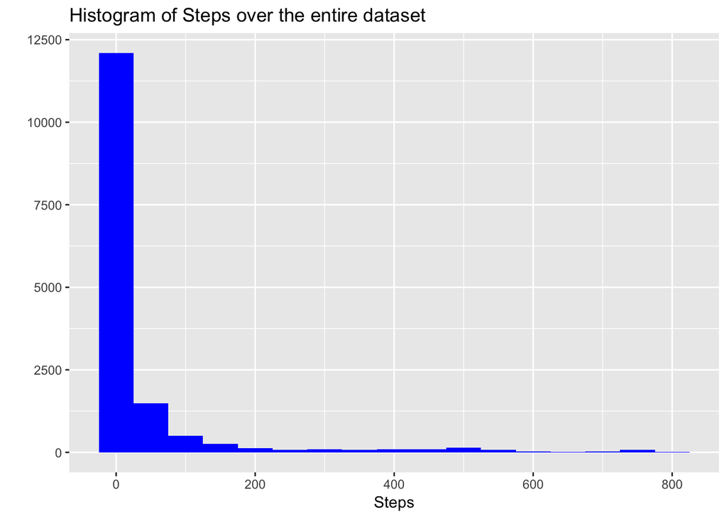

## Find which days are weekends

```r
charday <- as.character(activity$day)
table(charday)
```

```
## charday
##    Friday    Monday  Saturday    Sunday  Thursday   Tuesday Wednesday
##      2592      2592      2304      2304      2592      2592      2592
```

```r
dSunday<-as.numeric((activity$day=="Sunday"))
dMonday<-as.numeric((activity$day=="Monday"))
dTuesday<-as.numeric((activity$day=="Tuesday"))
dWednesday<-as.numeric((activity$day=="Wednesday"))
dThursday<-as.numeric((activity$day=="Thursday"))
dFriday<-as.numeric((activity$day=="Friday"))
dSaturday<-as.numeric((activity$day=="Saturday"))
dweekend<-dSunday+dSaturday
activity$dweekend <- dweekend
table(dweekend)
```

```
## dweekend
##     0     1
## 12960  4608
```

Now we have to handle missing values. I replaced with nonnegative predicted values based on a simple regression with day dummies and interval dummies. I then forced the values to be non-negative. A slightly better model would employ censored regression or something like that.

```r
#
#  regression model with non-interacted day and interval dummies
#
model_steps <- lm(steps ~ as.factor(day)+as.factor(interval), data=activity)
# summary(model_steps)
activity$missing_steps <- as.numeric(is.na(activity$steps))
table(activity$missing_steps)
```

```
##
##     0     1
## 15264  2304
```

```r
n_missing <- sum(activity$missing_steps)
# n_missing
activity$pred_steps=predict(model_steps,activity)
summary(activity$pred_steps)
```

```
##    Min. 1st Qu.  Median    Mean 3rd Qu.    Max.
##  -8.866   6.308  33.237  37.574  53.762 212.313
```

```r
str(activity$pred_steps)
```

```
##  num [1:17568] -1.03 -2.41 -2.62 -2.6 -2.67 ...
```

```r
activity$imputed_steps<-activity$steps
summary(activity$imputed_steps)
```

```
##    Min. 1st Qu.  Median    Mean 3rd Qu.    Max.    NA's
##    0.00    0.00    0.00   37.38   12.00  806.00    2304
```

```r
str(activity$imputed_steps)
```

```
##  int [1:17568] NA NA NA NA NA NA NA NA NA NA ...
```

```r
#
# loop through each observation
#
for(i in 1:nrow(activity))
{
  activity$imputed_steps[i]<- activity$steps[i]
  if(activity$missing_steps[i] == 1)
  {
    #
    #    Note that I want predicted values to be nonnegative. Which I do below.
    #
    activity$imputed_steps[i] <- max(0,activity$pred_steps[i])
  }
}
summary(activity$imputed_steps_missing)
```

```
## Length  Class   Mode
##      0   NULL   NULL
```

```r
str(activity$imputed_steps_missing)
```

[output not shown]

```r
summary(activity$steps)
```

```
##    Min. 1st Qu.  Median    Mean 3rd Qu.    Max.    NA's
##    0.00    0.00    0.00   37.38   12.00  806.00    2304
```

```r
summary(activity$imputed_steps)
```

```
##    Min. 1st Qu.  Median    Mean 3rd Qu.    Max.
##    0.00    0.00    0.00   37.63   27.27  806.00
```

```r
summary(activity$missing_steps)
```

```
##    Min. 1st Qu.  Median    Mean 3rd Qu.    Max.
##  0.0000  0.0000  0.0000  0.1311  0.0000  1.0000
```

```r
str(activity$steps)
```

```
##  int [1:17568] NA NA NA NA NA NA NA NA NA NA ...
```

```r
str(activity$imputed_steps)
```

```
##  num [1:17568] 0 0 0 0 0 0 0 0 0 0 ...
```

```r
str(activity$missing_steps)
```

```
##  num [1:17568] 1 1 1 1 1 1 1 1 1 1 ...
```

```r
imputed_steps <- activity$imputed_steps
activity_date <- activity$date
interval <-activity$interval
```

```r
#
# create weekend and weekday imputed step stuff. Loop through all the data and
# fill in the weekend and weekday vales.
#
for(i in 1:nrow(activity))
{
  if(activity$dweekend[i] == 1)
  {
    #
    #    Note that I want predicted values to be nonnegative. Which I do below.
    #
    activity$weekend_steps[i] <- activity$imputed_steps[i]
    activity$weekday_steps[i] <- NA
    activity$day_class_factor <- "Weekend"
  }
  if(activity$dweekend[i] == 0)
  {
    #
    #    Note that I want predicted values to be nonnegative. Which I do below.
    #
    activity$weekday_steps[i] <- activity$imputed_steps[i]
    activity$weekend_steps[i] <- NA
    activity$day_class_factor <- "Weekday"
  }
}
summary(activity$weekday_steps)
```

```
##    Min. 1st Qu.  Median    Mean 3rd Qu.    Max.    NA's
##    0.00    0.00    0.00   35.69   24.00  806.00    4608
```

```r
#
#
#
weekend_activity <- subset (activity,dweekend==1)
str(weekend_activity)
```

```
## 'data.frame':    4608 obs. of  12 variables:
##  $ steps           : int  0 0 0 0 0 0 0 0 0 0 ...
##  $ date            : Factor w/ 61 levels "2012-10-01","2012-10-02",..: 6 6 6 6 6 6 6 6 6 6 ...
##  $ interval        : int  0 5 10 15 20 25 30 35 40 45 ...
##  $ lsteps          : num  0 0 0 0 0 0 0 0 0 0 ...
##  $ day             : chr  "Saturday" "Saturday" "Saturday" "Saturday" ...
##  $ dweekend        : num  1 1 1 1 1 1 1 1 1 1 ...
##  $ missing_steps   : num  0 0 0 0 0 0 0 0 0 0 ...
##  $ pred_steps      : num  7.86 6.48 6.28 6.29 6.22 ...
##  $ imputed_steps   : num  0 0 0 0 0 0 0 0 0 0 ...
##  $ weekday_steps   : num  NA NA NA NA NA NA NA NA NA NA ...
##  $ weekend_steps   : num  0 0 0 0 0 0 0 0 0 0 ...
##  $ day_class_factor: chr  "Weekday" "Weekday" "Weekday" "Weekday" ...
```

```r
summary(weekend_activity)
```

```
##      steps                date         interval          lsteps
##  Min.   :  0.00   2012-10-06: 288   Min.   :   0.0   Min.   :0.000
##  1st Qu.:  0.00   2012-10-07: 288   1st Qu.: 588.8   1st Qu.:0.000
##  Median :  0.00   2012-10-13: 288   Median :1177.5   Median :0.000
##  Mean   : 43.08   2012-10-14: 288   Mean   :1177.5   Mean   :1.343
##  3rd Qu.: 24.00   2012-10-20: 288   3rd Qu.:1766.2   3rd Qu.:3.219
##  Max.   :785.00   2012-10-21: 288   Max.   :2355.0   Max.   :6.667
##  NA's   :576      (Other)   :2880                    NA's   :576
##      day               dweekend missing_steps     pred_steps
##  Length:4608        Min.   :1   Min.   :0.000   Min.   :  5.248
##  Class :character   1st Qu.:1   1st Qu.:0.000   1st Qu.:  8.182
##  Mode  :character   Median :1   Median :0.000   Median : 39.809
##                     Mean   :1   Mean   :0.125   Mean   : 43.078
##                     3rd Qu.:1   3rd Qu.:0.000   3rd Qu.: 58.654
##                     Max.   :1   Max.   :1.000   Max.   :212.313
##
##  imputed_steps    weekday_steps  weekend_steps    day_class_factor
##  Min.   :  0.00   Min.   : NA    Min.   :  0.00   Length:4608
##  1st Qu.:  0.00   1st Qu.: NA    1st Qu.:  0.00   Class :character
##  Median :  0.00   Median : NA    Median :  0.00   Mode  :character
##  Mean   : 43.08   Mean   :NaN    Mean   : 43.08
##  3rd Qu.: 37.57   3rd Qu.: NA    3rd Qu.: 37.57
##  Max.   :785.00   Max.   : NA    Max.   :785.00
##                   NA's   :4608
```

```r
weekday_activity <- subset (activity,dweekend==0)
str(weekday_activity)
```

```
## 'data.frame':    12960 obs. of  12 variables:
##  $ steps           : int  NA NA NA NA NA NA NA NA NA NA ...
##  $ date            : Factor w/ 61 levels "2012-10-01","2012-10-02",..: 1 1 1 1 1 1 1 1 1 1 ...
##  $ interval        : int  0 5 10 15 20 25 30 35 40 45 ...
##  $ lsteps          : num  NA NA NA NA NA NA NA NA NA NA ...
##  $ day             : chr  "Monday" "Monday" "Monday" "Monday" ...
##  $ dweekend        : num  0 0 0 0 0 0 0 0 0 0 ...
##  $ missing_steps   : num  1 1 1 1 1 1 1 1 1 1 ...
##  $ pred_steps      : num  -1.03 -2.41 -2.62 -2.6 -2.67 ...
##  $ imputed_steps   : num  0 0 0 0 0 0 0 0 0 0 ...
##  $ weekday_steps   : num  0 0 0 0 0 0 0 0 0 0 ...
##  $ weekend_steps   : num  NA NA NA NA NA NA NA NA NA NA ...
##  $ day_class_factor: chr  "Weekday" "Weekday" "Weekday" "Weekday" ...
```

```r
summary(weekday_activity)
```

```
##      steps                date          interval          lsteps
##  Min.   :  0.00   2012-10-01:  288   Min.   :   0.0   Min.   :0.000
##  1st Qu.:  0.00   2012-10-02:  288   1st Qu.: 588.8   1st Qu.:0.000
##  Median :  0.00   2012-10-03:  288   Median :1177.5   Median :0.000
##  Mean   : 35.34   2012-10-04:  288   Mean   :1177.5   Mean   :1.088
##  3rd Qu.:  8.00   2012-10-05:  288   3rd Qu.:1766.2   3rd Qu.:2.197
##  Max.   :806.00   2012-10-08:  288   Max.   :2355.0   Max.   :6.693
##  NA's   :1728     (Other)   :11232                    NA's   :1728
##      day               dweekend missing_steps      pred_steps
##  Length:12960       Min.   :0   Min.   :0.0000   Min.   : -8.866
##  Class :character   1st Qu.:0   1st Qu.:0.0000   1st Qu.:  5.533
##  Mode  :character   Median :0   Median :0.0000   Median : 31.654
##                     Mean   :0   Mean   :0.1333   Mean   : 35.616
##                     3rd Qu.:0   3rd Qu.:0.0000   3rd Qu.: 51.726
##                     Max.   :0   Max.   :1.0000   Max.   :211.703
##
##  imputed_steps    weekday_steps    weekend_steps   day_class_factor
##  Min.   :  0.00   Min.   :  0.00   Min.   : NA     Length:12960
##  1st Qu.:  0.00   1st Qu.:  0.00   1st Qu.: NA     Class :character
##  Median :  0.00   Median :  0.00   Median : NA     Mode  :character
##  Mean   : 35.69   Mean   : 35.69   Mean   :NaN
##  3rd Qu.: 24.00   3rd Qu.: 24.00   3rd Qu.: NA
##  Max.   :806.00   Max.   :806.00   Max.   : NA
##                                    NA's   :12960
```

Set up a weekend factor

```r
activity$weekend_factor <- as.factor(activity$dweekend)
```

This code is to be ignored. Left here as a template for me for future use

```r
#xyplot(week_activity$imputed_steps ~ week_activity$interval | factor(as.factor(week_activity$dweekend),type="l", xlab = "Interval",ylab = "Steps"))
# xyplot(week_activity$imputed_steps ~ week_activity$interval , xlab = "Interval",ylab = "Steps")
```

Now deal with daily averages using aggregate.

```r
#
# First compute average by day
#
day_imputed_steps <- aggregate(imputed_steps,list(activity_day= activity_date),sum)
day_imputed_steps$daily_steps <- day_imputed_steps$x
str(day_imputed_steps)
```

```
## 'data.frame':    61 obs. of  3 variables:
##  $ activity_day: Factor w/ 61 levels "2012-10-01","2012-10-02",..: 1 2 3 4 5 6 7 8 9 10 ...
##  $ x           : num  10130 126 11352 12116 13294 ...
##  $ daily_steps : num  10130 126 11352 12116 13294 ...
```

```r
summary(day_imputed_steps$daily_steps)
```

```
##    Min. 1st Qu.  Median    Mean 3rd Qu.    Max.
##      41    8918   11015   10838   12811   21194
```

```r
#
# now average intervals
#
interval_imputed_steps <- aggregate(imputed_steps,list(activity_interval= interval),mean)
interval_imputed_steps$interval_steps_imputed <- interval_imputed_steps$x
str(interval_imputed_steps)
```

```
## 'data.frame':    288 obs. of  3 variables:
##  $ activity_interval     : int  0 5 10 15 20 25 30 35 40 45 ...
##  $ x                     : num  2.059 0.749 0.552 0.57 0.498 ...
##  $ interval_steps_imputed: num  2.059 0.749 0.552 0.57 0.498 ...
```

```r
summary(interval_imputed_steps)
```

```
##  activity_interval       x            interval_steps_imputed
##  Min.   :   0.0    Min.   :  0.4265   Min.   :  0.4265
##  1st Qu.: 588.8    1st Qu.:  2.7901   1st Qu.:  2.7901
##  Median :1177.5    Median : 34.3043   Median : 34.3043
##  Mean   :1177.5    Mean   : 37.6306   Mean   : 37.6306
##  3rd Qu.:1766.2    3rd Qu.: 53.0260   3rd Qu.: 53.0260
##  Max.   :2355.0    Max.   :206.3609   Max.   :206.3609
```

```r
#
# day_imputed_steps
```

Now show weekend and weekday separately

```r
interval_imputed_weekend_steps <- aggregate(activity$weekend_steps,list(activity_interval= interval),mean)
interval_imputed_weekend_steps <- interval_imputed_weekend_steps$x
str(interval_imputed_weekend_steps)
```

```
##  num [1:288] NA NA NA NA NA NA NA NA NA NA ...
```

```r
summary(interval_imputed_weekend_steps)
```

```
##    Min. 1st Qu.  Median    Mean 3rd Qu.    Max.    NA's
##      NA      NA      NA     NaN      NA      NA     288
```

Now find the interval with the largest average number of (imputed) steps, and the corresponding number of steps.

One notice. This is a resubmission. I noticed during peer grading that I had made a careless error in my original code. The maximum answer was correct, but my answer of“835” had the benefit of seeing the correct code.

```r
#
#  find the maximum imputed steps
#
max_interval <- interval_imputed_steps[which.max(interval_imputed_steps$interval_steps_imputed),1]
max_interval
```

```
## [1] 835
```

```r
#
# maximum value of steps
#
max(interval_imputed_steps$interval_steps_imputed)
```

```
## [1] 206.3609
```

```r
interval_imputed_steps[which.max(interval_imputed_steps$interval_steps_imputed),3]
```

```
## [1] 206.3609
```

## Now show some graphs

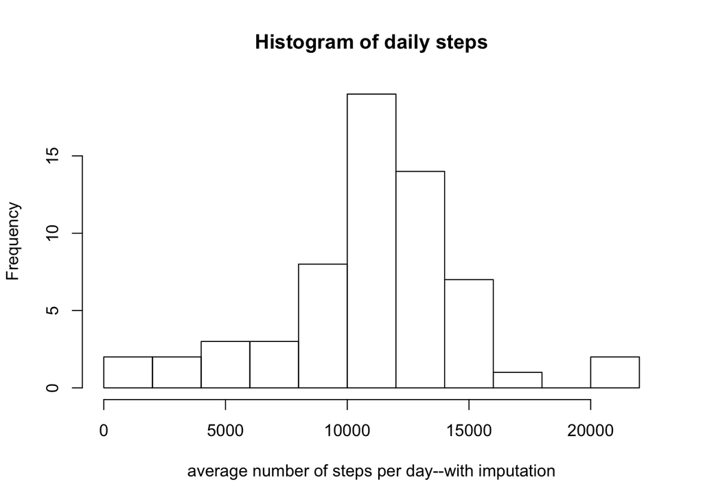

```r
## log of steps
#
#     I commented out the logs here
#
hist(day_imputed_steps$daily_steps ,
      breaks = 10,
      main="Histogram of daily steps",
     xlab = "average number of steps per day--with imputation",
     )
```

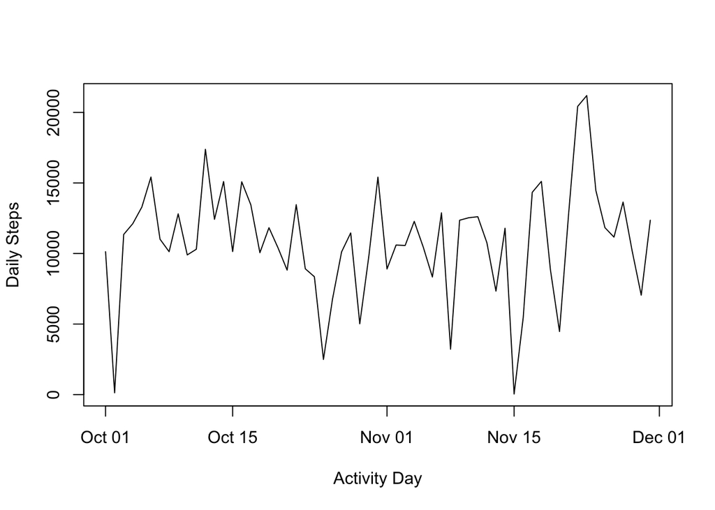

```r
#
# time series by day
#
plot(as.Date(day_imputed_steps$activity_day),day_imputed_steps$daily_steps, type="l", xlab = "Activity Day",ylab = "Daily Steps")
```

```r
# xyplot(as.Date(day_imputed_steps$activity_day),day_imputed_steps$daily_steps|day_imputed_steps$dweekend)
day_imputed_steps$day_of_week <-weekdays(as.Date(day_imputed_steps$activity_day))
# ggplot(day_imputed_steps)+geom_line(aes(x=activity_day,y=daily_steps))
#
#   Time series by 5-minute interval
#
table(day_imputed_steps$day_of_week)
```

```
##
##    Friday    Monday  Saturday    Sunday  Thursday   Tuesday Wednesday
##         9         9         8         8         9         9         9
```

```r
dSunday<-as.numeric((day_imputed_steps$day_of_week=="Sunday"))
dSaturday<-as.numeric((day_imputed_steps$day_of_week=="Saturday"))
day_imputed_steps$dweekend<-as.numeric(dSunday+dSaturday)
table(day_imputed_steps$dweekend)
```

```
##
##  0  1
## 45 16
```

```r
for(i in 1:nrow(day_imputed_steps))
{
  day_imputed_steps$day_class[i]<- "weekday"
  if(day_imputed_steps$dweekend[i] == 1)
  {
    #
    #    Note that I want predicted values to be nonnegative. Which I do below.
    #
    day_imputed_steps$day_class[i]<- "weekend"
  }
}
day_imputed_steps$day_class<- as.factor(day_imputed_steps$day_class)
table(day_imputed_steps$day_class)
```

```
##
## weekday weekend
##      45      16
```

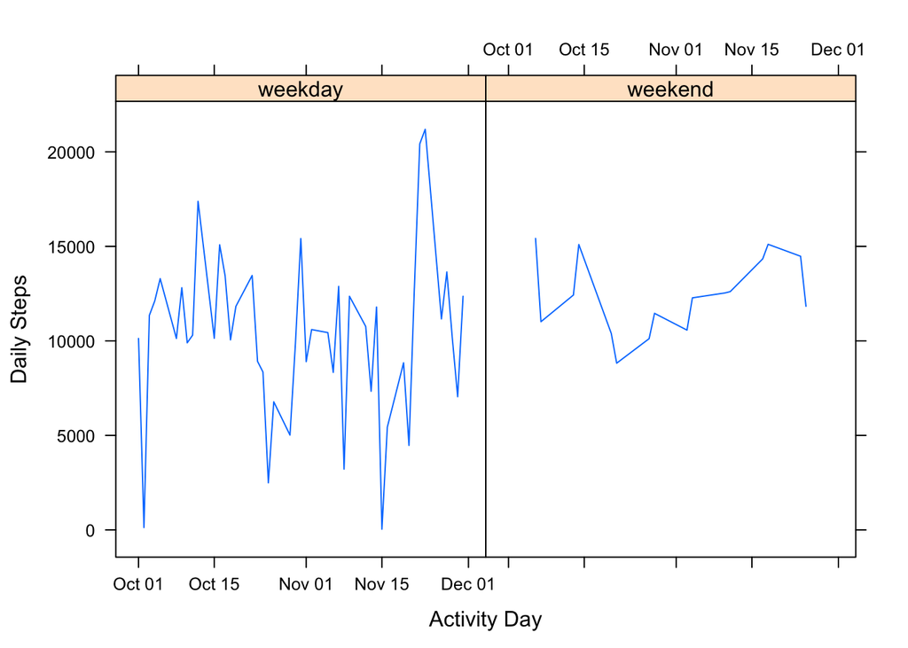

```r
xyplot(day_imputed_steps$daily_steps ~ as.Date(day_imputed_steps$activity_day) | factor(day_imputed_steps$day_class),type="l", xlab = "Activity Day",ylab = "Daily Steps")
```

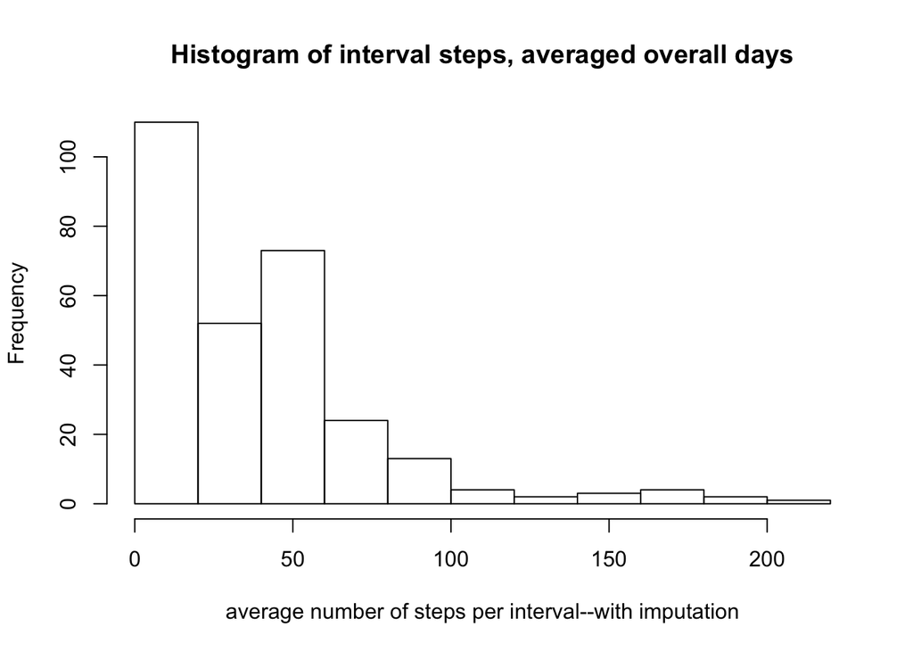

```r
hist(interval_imputed_steps$interval_steps_imputed,
      breaks = 10,
      main="Histogram of interval steps, averaged overall days",
      xlab = "average number of steps per interval--with imputation",
      )
```

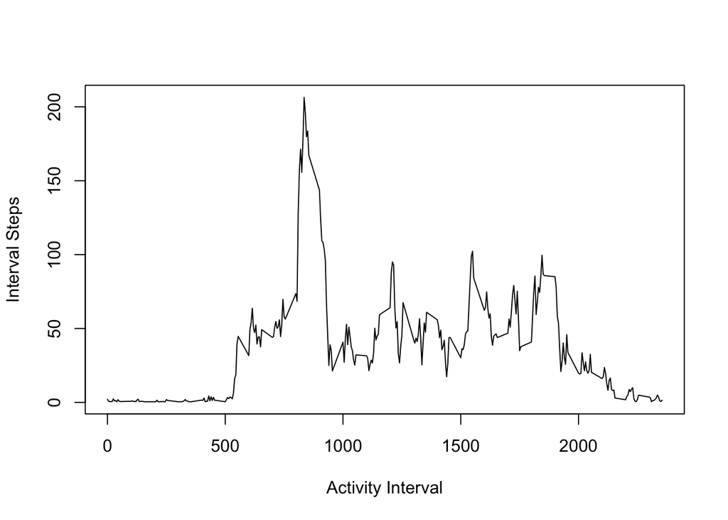

```r
plot(interval_imputed_steps$activity_interval,interval_imputed_steps$interval_steps_imputed, type="l",xlab = "Activity Interval",ylab = "Interval Steps")
```

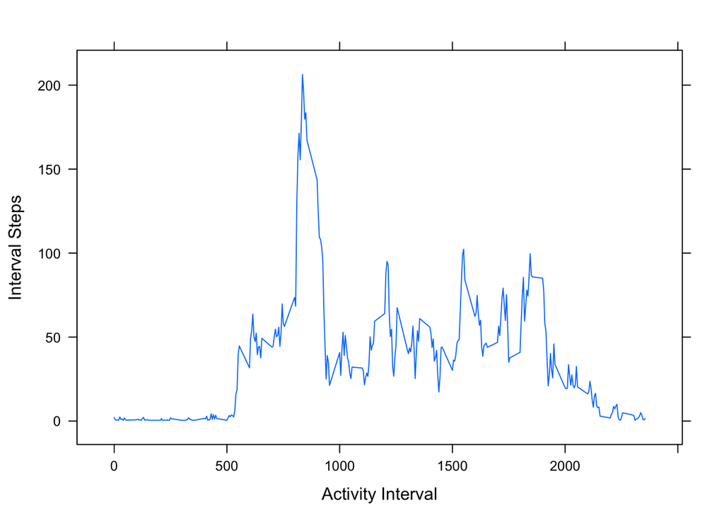

```r
xyplot(interval_imputed_steps$interval_steps_imputed ~ interval_imputed_steps$activity_interval, type="l",xlab = "Activity Interval",ylab = "Interval Steps")
```

Now weekend and weekday intervals

```r
#
# now average intervals
#
weekend_interval_imputed_steps <- aggregate(weekend_activity$imputed_steps,list(weekend_activity_interval= weekend_activity$interval),mean)
weekend_interval_imputed_steps$interval_steps_imputed <- weekend_interval_imputed_steps$x
#
# remove x
#
weekend_interval_imputed_steps$x <- NULL
#
# descriptives on weekend
#
str(weekend_interval_imputed_steps)
```

```
## 'data.frame':    288 obs. of  2 variables:
##  $ weekend_activity_interval: int  0 5 10 15 20 25 30 35 40 45 ...
##  $ interval_steps_imputed   : num  0.927 0.754 0.728 0.731 0.721 ...
```

```r
summary(weekend_interval_imputed_steps)
```

```
##  weekend_activity_interval interval_steps_imputed
##  Min.   :   0.0            Min.   :  0.712
##  1st Qu.: 588.8            1st Qu.:  1.953
##  Median :1177.5            Median : 33.052
##  Mean   :1177.5            Mean   : 43.078
##  3rd Qu.:1766.2            3rd Qu.: 75.366
##  Max.   :2355.0            Max.   :167.351
```

Now weekday code

```r
#
# now average intervals
#
weekday_interval_imputed_steps <- aggregate(weekday_activity$imputed_steps,list(weekday_activity_interval= weekday_activity$interval),mean)
weekday_interval_imputed_steps$interval_steps_imputed <- weekday_interval_imputed_steps$x
str(weekday_interval_imputed_steps)
```

```
## 'data.frame':    288 obs. of  3 variables:
##  $ weekday_activity_interval: int  0 5 10 15 20 25 30 35 40 45 ...
##  $ x                        : num  2.462 0.748 0.489 0.513 0.419 ...
##  $ interval_steps_imputed   : num  2.462 0.748 0.489 0.513 0.419 ...
```

```r
summary(weekday_interval_imputed_steps)
```

```
##  weekday_activity_interval       x           interval_steps_imputed
##  Min.   :   0.0            Min.   :  0.325   Min.   :  0.325
##  1st Qu.: 588.8            1st Qu.:  2.415   1st Qu.:  2.415
##  Median :1177.5            Median : 25.809   Median : 25.809
##  Mean   :1177.5            Mean   : 35.694   Mean   : 35.694
##  3rd Qu.:1766.2            3rd Qu.: 50.860   3rd Qu.: 50.860
##  Max.   :2355.0            Max.   :230.384   Max.   :230.384
```

## Now show the weeken/weekday graphs and the multi-panel

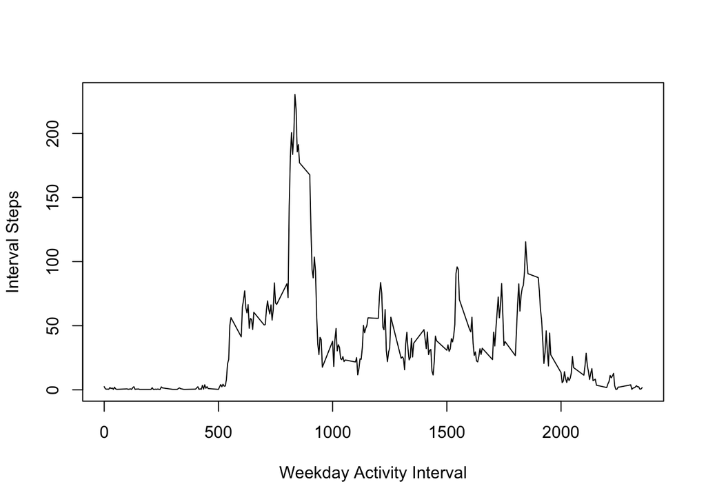

```r
p1 <- plot(weekday_interval_imputed_steps$weekday_activity_interval,weekday_interval_imputed_steps$interval_steps_imputed, type="l",xlab = "Weekday Activity Interval",ylab = "Interval Steps")
```

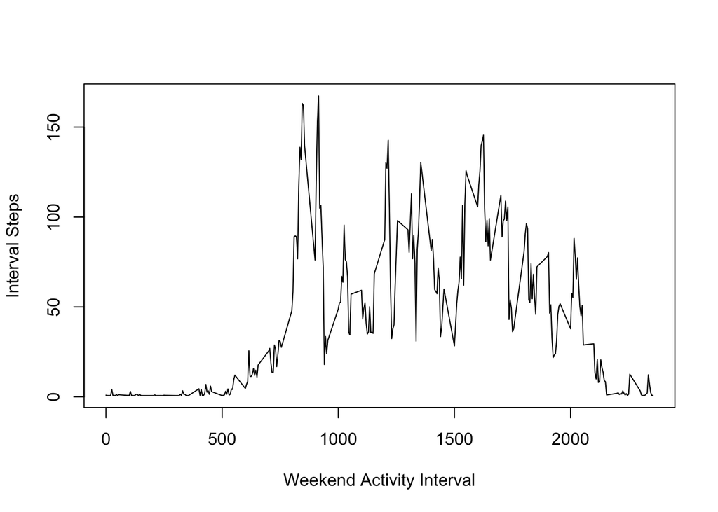

```r
p2 <- plot(weekend_interval_imputed_steps$weekend_activity_interval,weekend_interval_imputed_steps$interval_steps_imputed, type="l",xlab = "Weekend Activity Interval",ylab = "Interval Steps")
```

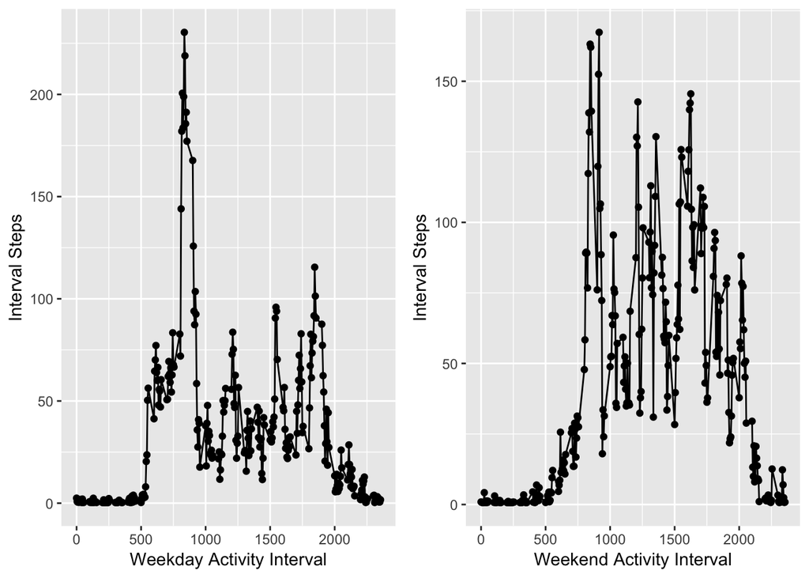

```r
q1 <- qplot(weekday_interval_imputed_steps$weekday_activity_interval,weekday_interval_imputed_steps$interval_steps_imputed,xlab = "Weekday Activity Interval",ylab = "Interval Steps", geom=c("point", "line"))
q2 <- qplot(weekend_interval_imputed_steps$weekend_activity_interval,weekend_interval_imputed_steps$interval_steps_imputed,xlab = "Weekend Activity Interval",ylab = "Interval Steps", geom=c("point", "line"))

grid.arrange (q1, q2, nrow = 1)
```

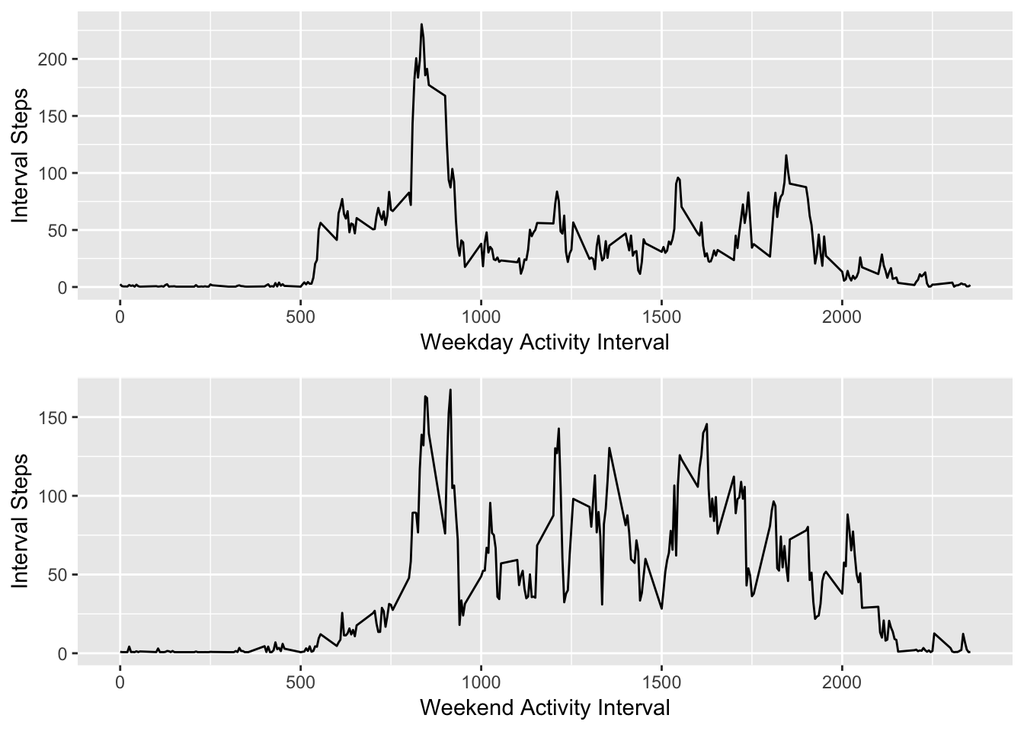

```r
#
#     Let's see the pure line graph
#
q3 <- qplot(weekday_interval_imputed_steps$weekday_activity_interval,weekday_interval_imputed_steps$interval_steps_imputed,xlab = "Weekday Activity Interval",ylab = "Interval Steps", geom=c("line"))
q4 <- qplot(weekend_interval_imputed_steps$weekend_activity_interval,weekend_interval_imputed_steps$interval_steps_imputed,xlab = "Weekend Activity Interval",ylab = "Interval Steps", geom=c("line"))

grid.arrange (q3, q4, ncol = 1)
```